# Dataset Analysis

Benjamin Tenmann

12/02/2022

## Introduction

In this notebook, I intend to get a birds-eye view of the dataset in question: `Pfam seed random split`.

Protein family classification is the task of assigning a set of family domain IDs to a peptide. A protein domain is a section of the protein’s sequence which performs a specific function. In this dataset, each example is an isolated domain with its associated family ID.

A good example for a protein containing multiple domains is the superfamily of G-protein coupled receptors, which are a diverse set of cell-surface receptors involved in a variety of cell-signalling tasks. It consists of seven transmembrane domains, connected by three intracellular and three extracellular loops, of which the extracellular loops form the ligand-binding domain.

```r
library(rjson)
library(tidyverse)
```

As a first step, let’s load the data into memory (~ 1 million examples is manageable).

```r
DATA_DIR <- "data/random_split"
FILES <- list.files(
  path = DATA_DIR,
  pattern = "*.jsonl",
  full.names = TRUE
)

FILES %>%
  map(function(x) {
    readLines(x) %>%
      map(fromJSON) %>%
      bind_rows()
  }) %>%
  bind_rows() -> df
```

## Sanity Check

To be sure that we have all the data, let’s see how many examples we have for each split and how many examples in total.

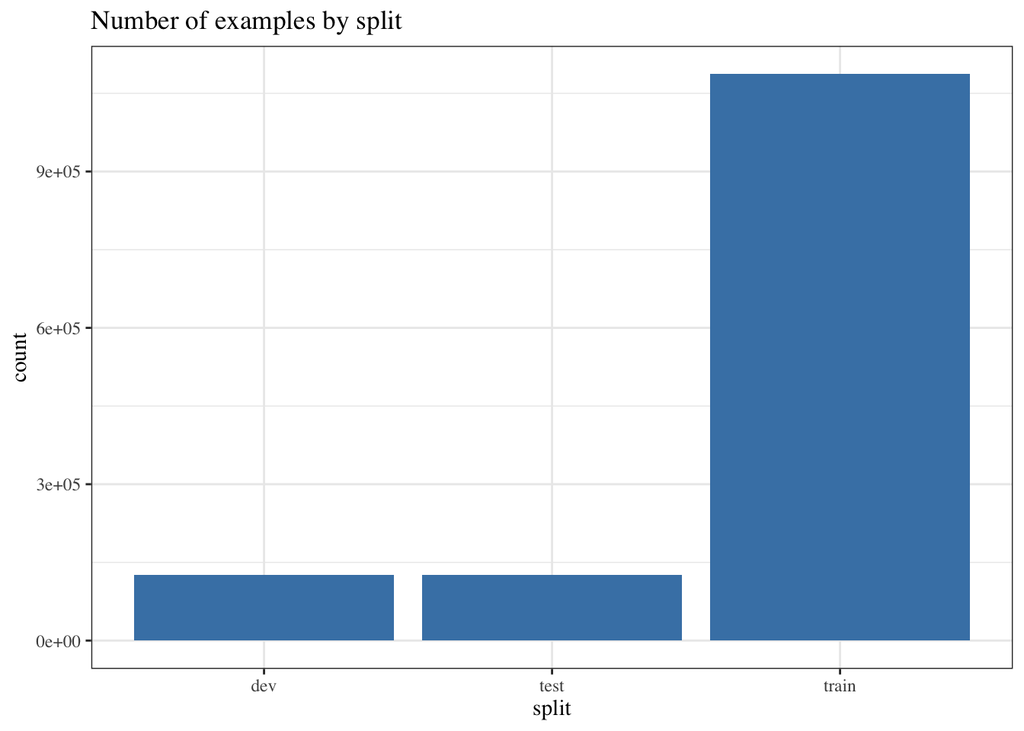

```r
df %>%
  group_by(split) %>%
  count() -> tmp

tmp %>%
  ggplot(aes(x = split, y = n))+
  geom_bar(stat = "identity", fill = "steelblue")+
  labs(
    title = "Number of examples by split",
    y = "count"
  )+
  theme_bw()+
  theme(text = element_text(family = "Times"))
```

The total number of examples is 1339083 (~ 1.34m according to the paper). We also want to check that we have the right number of families.

```r
n_classes <- df$family_id %>%
  unique() %>%
  length()
```

From this we get a total of 17929 (17929 in the paper).

## Distribution Analysis

Now that we have validated that everything is in its right place, we can look at some summary statistics and distributions of the data. First off, let’s look at the distribution of (unaligned) sequence lengths.

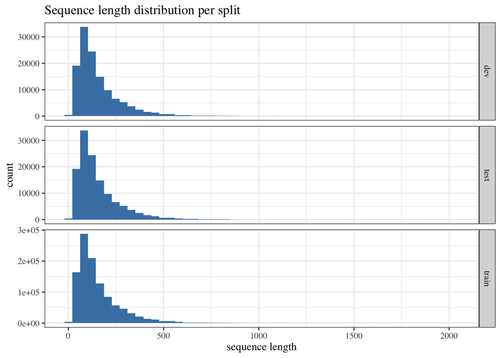

```r
df %>%
  mutate(sequence_length = str_length(sequence)) %>%
  ggplot(aes(x = sequence_length))+
  geom_histogram(bins = 50, fill = "steelblue")+
  labs(
    title = "Sequence length distribution per split",
    x = "sequence length"
  )+
  theme_bw()+
  theme(text = element_text(family = "Times"))+
  facet_grid(split ~ ., scales = "free_y")
```

Next, we will look at the distribution of abundances for each family, i.e. the number of examples we have for each class.

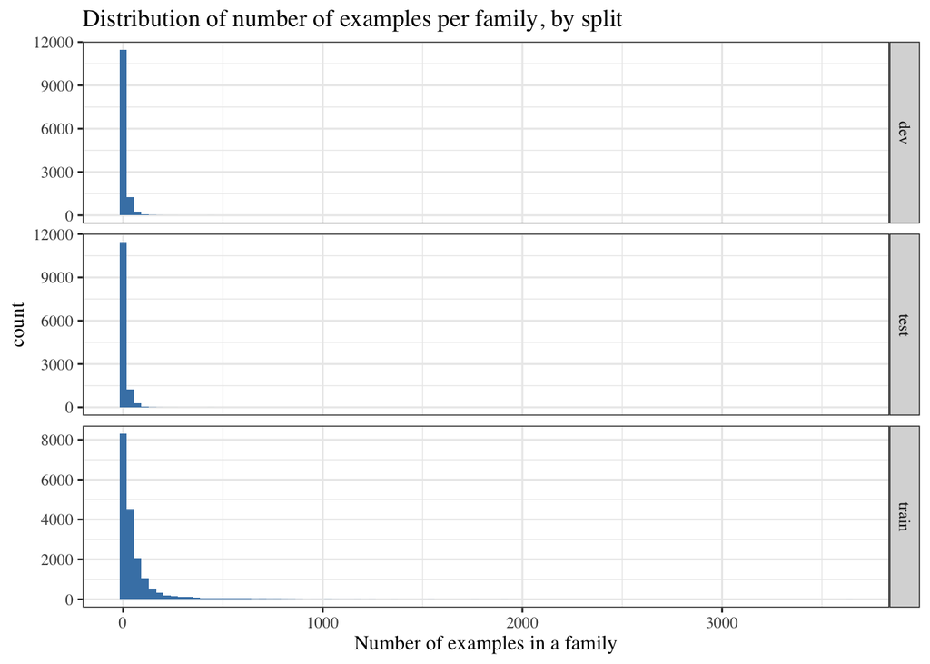

```r
df %>%
  group_by(split, family_id) %>%
  count() -> tmp

tmp %>%
  ggplot(aes(x = n))+
  geom_histogram(bins = 100, fill = "steelblue")+
  labs(
    title = "Distribution of number of examples per family, by split",
    x = "Number of examples in a family"
  )+
  theme_bw()+
  theme(text = element_text(family = "Times"))+
  facet_grid(split ~ ., scales = "free_y")
```

Below we have a small summary table for the same data:

| split | min | q1 | median | q3 | mean | sd | max |
| --- | --- | --- | --- | --- | --- | --- | --- |
| dev | 1 | 2 | 4 | 10 | 9.652743 | 16.15364 | 454 |
| test | 1 | 2 | 4 | 10 | 9.652743 | 16.15364 | 454 |
| train | 1 | 8 | 22 | 65 | 60.613587 | 115.62323 | 3637 |